# 서울대공원 입장객 데이터 분석

### 판다스와 시각화 모듈로 서울대공원 입장객수 분석해보기

서울대공원에 놀러가본적 있나요? 서울대공원은 경기도 과천에 위치한 테마파크입니다. (어렸을 적에 왜..서울대공원인데 경기도에 있지? 가 궁금해 했던 기억이 나네요ㅎㅎ)

서울대공원은 동물원, 식물원 뿐만 아니라 놀이공원, 미술관, 캠핑장까지 보유하고 있습니다.

https://grandpark.seoul.go.kr/

이번에는 서울대공원 입장객 데이터를 가지고 Pandas를 연습하고 시각화까지 배워보도록 하겠습니다.

우선 서울대공원 입장객 데이터를 가지고 와보겠습니다.

아래 링크에서 데이터를 제공하네요.

(원할한 연습을 위해 원본 데이터를 조금 수정하였습니다.)

https://www.data.go.kr/dataset/15033810/fileData.do

우선 판다스 모듈을 불러옵니다.

```python
import pandas as pd
```

```python
df=pd.read_csv('data/Seoul_Park.csv')
```

데이터를 살펴보도록 하죠.

먼저 shape로 행렬 사이즈를 확인합니다.

```python
df.shape
```

```
(1086, 12)
```

1086개의 row와 12개의 column로 구성되어 있는 데이터네요

컬럼을 살펴보겠습니다

column을 살펴보면 '날짜', '요일', '날씨' 데이터가 있고 그에 따른 '유료합계', '어른', '청소년', '어린이', '외국인', '단체', '무료합계', '총계' 데이터가 있습니다.

```python
df.columns
```

```
Index(['날짜', '요일', '공휴일', '날씨', '유료합계', '어른', '청소년', '어린이', '외국인', '단체',
       '무료합계', '총계'],
      dtype='object')
```

### 컬럼 설명

- 날짜 : 연-월-일로 표현합니다.
- 요일 : 해당 날짜의 요일을 표현합니다.
- 공휴일 : 법정공휴일과 주말인 경우에 1로 표현하고 그 외의 날은 0으로 표현합니다.
- 날씨 : 구름 조금, 구름 많음, 맑음, 흐림, 눈, 비, 눈/비으로 표현합니다.
- 유료합계 : 입장객 중 유료입장객 수를 표현합니다.
- 어른 : 입장객 중 어른의 수를 표현합니다.
- 청소년 : 입장객 중 청소년의 수를 표현합니다.
- 어린이 : 입장객 중 어린이의 수를 표현합니다.
- 외국인 : 입장객 중 외국인의 수를 표현합니다.
- 단체 : 입장객 중 단체입장객 수를 표현합니다.
- 무료합계 : 입장객 중 무료합계 수를 표현합니다.
- 총계 : 입장객 총 수를 표현합니다.

이제 데이터프레임을 봅시다. 상위 5개도 먼저 보겠습니다.

```python
df.head()
```

|  | 날짜 | 요일 | 공휴일 | 날씨 | 유료합계 | 어른 | 청소년 | 어린이 | 외국인 | 단체 | 무료합계 | 총계 |
| --- | --- | --- | --- | --- | --- | --- | --- | --- | --- | --- | --- | --- |
| 0 | 2016-01-01 | 금 | 1 | 구름 조금 | 3,359 | 2,799 | 141 | 419 | 47 | 0 | 1,023 | 4,382 |
| 1 | 2016-01-02 | 토 | 1 | 구름 많음 | 5,173 | 4,370 | 203 | 600 | 100 | 111 | 2,092 | 7,265 |
| 2 | 2016-01-03 | 일 | 1 | 구름 많음 | 3,008 | 2,571 | 128 | 309 | 91 | 0 | 1,549 | 4,557 |
| 3 | 2016-01-04 | 월 | 0 | 구름 많음 | 890 | 602 | 53 | 235 | 51 | 223 | 800 | 1,690 |
| 4 | 2016-01-05 | 화 | 0 | 구름 많음 | 416 | 319 | 35 | 62 | 43 | 47 | 840 | 1,256 |

하위 5개도 보죠

```python
df.tail()
```

|  | 날짜 | 요일 | 공휴일 | 날씨 | 유료합계 | 어른 | 청소년 | 어린이 | 외국인 | 단체 | 무료합계 | 총계 |
| --- | --- | --- | --- | --- | --- | --- | --- | --- | --- | --- | --- | --- |
| 1081 | 2019-03-27 | 수 | 0 | 구름 많음 | 504 | 464 | 10 | 30 | 21 | - | 613 | 1,117 |
| 1082 | 2019-03-28 | 목 | 0 | 구름 많음 | 761 | 687 | 46 | 28 | 35 | 108 | 904 | 1,665 |
| 1083 | 2019-03-29 | 금 | 0 | 구름 조금 | 1,644 | 1,447 | 120 | 77 | 14 | 188 | 1,226 | 2,870 |
| 1084 | 2019-03-30 | 토 | 1 | 흐림 | 1,539 | 1,326 | 44 | 169 | 29 | 115 | 913 | 2,452 |
| 1085 | 2019-03-31 | 일 | 1 | 구름 조금 | 3,061 | 2,563 | 111 | 387 | 53 | - | 1,357 | 4,418 |

info()함수를 사용하면 각 column들의 정보를 확인할 수 있습니다.

```python
df.info()
```

```
<class 'pandas.core.frame.DataFrame'>
RangeIndex: 1086 entries, 0 to 1085
Data columns (total 12 columns):
 #   Column  Non-Null Count  Dtype
---  ------  --------------  -----
 0   날짜      1086 non-null   object
 1   요일      1086 non-null   object
 2   공휴일     1086 non-null   int64
 3   날씨      946 non-null    object
 4   유료합계    1086 non-null   object
 5   어른      1086 non-null   object
 6   청소년     1086 non-null   object
 7   어린이     1086 non-null   object
 8   외국인     1086 non-null   object
 9   단체      1086 non-null   object
 10  무료합계    1086 non-null   object
 11  총계      1086 non-null   object
dtypes: int64(1), object(11)
memory usage: 101.9+ KB
```

공휴일 컬럼을 제외한 모든 컬럼이 문자열 형태이네요.

날씨 컬럼은 데이터의 갯수가 946개 밖에 되지 않네요. 결손값이 존재한다는 이야기지요

dtypes를 각 컬럼의 형태만 확인할 수 도 있습니다.

```python
df.dtypes
```

```
날짜      object
요일      object
공휴일      int64
날씨      object
유료합계    object
어른      object
청소년     object
어린이     object
외국인     object
단체      object
무료합계    object
총계      object
dtype: object
```

'유료합계', '어른', '청소년', '어린이', '외국인', '단체', '무료합계', '총계' 컬럼들은 모두 숫자형으로 바꿔줄 필요가 있습니다.

숫자형이 되어야 평균값과 같은 여러 가지 산술값을 구할 수 있으니까요.

그런데 숫자형으로 바꾸려보니 몇 가지 이슈가 발생하네요.

##### 1) 세 자리마다 쉼표 기호가 있어서 숫자형으로 변형이 바로 불가함

##### 2) 2019년에는 입장객 수가 없을 경우 0대신 '-'기호로 표시

이슈 1)을 먼저 해결해봅시다.

숫자형으로 변형해주고자 하는 컬럼명이 요소값으로 들어간 리스트를 만듭니다. 리스트 이름은 columns로 하구요.

```python
columns=['유료합계', '어른', '청소년', '어린이', '외국인', '단체', '무료합계', '총계']
```

그리고 함수 solution를 아래와 같이 정의합니다.

1. 문자열을 쉼표(,)를 기준으로 분리하여 리스트의 요소 값으로 넣음
2. 리스트의 요소값들을 합쳐서 문자열로 만들어줌

```python
def solution(a):
    b=a.split(',')
    c=''.join(b)
    return c
```

apply 와 lambda 표현식을 활용해서 solution 함수를 리스트 columns 의 모든 컬럼에 적용해봅시다.

아래와 같이 for문을 사용하면 가능하지요

```python
for i in columns:
    df[i]=df[i].apply(lambda e : solution(e))
```

```python
df.tail()
```

|  | 날짜 | 요일 | 공휴일 | 날씨 | 유료합계 | 어른 | 청소년 | 어린이 | 외국인 | 단체 | 무료합계 | 총계 |
| --- | --- | --- | --- | --- | --- | --- | --- | --- | --- | --- | --- | --- |
| 1081 | 2019-03-27 | 수 | 0 | 구름 많음 | 504 | 464 | 10 | 30 | 21 | - | 613 | 1117 |
| 1082 | 2019-03-28 | 목 | 0 | 구름 많음 | 761 | 687 | 46 | 28 | 35 | 108 | 904 | 1665 |
| 1083 | 2019-03-29 | 금 | 0 | 구름 조금 | 1644 | 1447 | 120 | 77 | 14 | 188 | 1226 | 2870 |
| 1084 | 2019-03-30 | 토 | 1 | 흐림 | 1539 | 1326 | 44 | 169 | 29 | 115 | 913 | 2452 |
| 1085 | 2019-03-31 | 일 | 1 | 구름 조금 | 3061 | 2563 | 111 | 387 | 53 | - | 1357 | 4418 |

이제 쉼표 기호를 없앴습니다. 이슈 1)을 해결했군요.ㅎㅎ

하지만 여전히 컬럼 데이터의 형태는 object(문자) 입니다.

그리고 이슈 2)를 해결해야 겠지요

이슈 2)를 해결하기 위해서 숫자형태로 변환할 때 오류가 발생하면 결손값 처리하고 대신 0을 넣도록 아래와 같이 코드를 작성합니다

```python
for i in columns:
    df[i]=pd.to_numeric(df[i], errors='coerce').fillna(0)
```

이제 리스트 columns의 모든 데이터들이 숫자형으로 바뀐 것을 확인할 수 있습니다

```python
df.dtypes
```

```
날짜       object
요일       object
공휴일       int64
날씨       object
유료합계      int64
어른        int64
청소년     float64
어린이       int64
외국인     float64
단체      float64
무료합계      int64
총계        int64
dtype: object
```

이번에는 날짜 컬럼의 데이터 형태를 datetime으로 바꿔보도록 하겠습니다.

```python
df.head()
```

|  | 날짜 | 요일 | 공휴일 | 날씨 | 유료합계 | 어른 | 청소년 | 어린이 | 외국인 | 단체 | 무료합계 | 총계 |
| --- | --- | --- | --- | --- | --- | --- | --- | --- | --- | --- | --- | --- |
| 0 | 2016-01-01 | 금 | 1 | 구름 조금 | 3359 | 2799 | 141.0 | 419 | 47.0 | 0.0 | 1023 | 4382 |
| 1 | 2016-01-02 | 토 | 1 | 구름 많음 | 5173 | 4370 | 203.0 | 600 | 100.0 | 111.0 | 2092 | 7265 |
| 2 | 2016-01-03 | 일 | 1 | 구름 많음 | 3008 | 2571 | 128.0 | 309 | 91.0 | 0.0 | 1549 | 4557 |
| 3 | 2016-01-04 | 월 | 0 | 구름 많음 | 890 | 602 | 53.0 | 235 | 51.0 | 223.0 | 800 | 1690 |
| 4 | 2016-01-05 | 화 | 0 | 구름 많음 | 416 | 319 | 35.0 | 62 | 43.0 | 47.0 | 840 | 1256 |

```python
df['날짜']= pd.to_datetime(df['날짜'])
```

```python
df.dtypes
```

```
날짜      datetime64[ns]
요일              object
공휴일              int64
날씨              object
유료합계             int64
어른               int64
청소년            float64
어린이              int64
외국인            float64
단체             float64
무료합계             int64
총계               int64
dtype: object
```

새로운 컬럼을 만들어서 연/월/일 데이터를 가지고 있게 해보지요

```python
df['연']=df['날짜'].dt.year
df['월']=df['날짜'].dt.month
df['일']=df['날짜'].dt.day
df['요일(num)']=df['날짜'].dt.dayofweek
```

```python
df.head()
```

|  | 날짜 | 요일 | 공휴일 | 날씨 | 유료합계 | 어른 | 청소년 | 어린이 | 외국인 | 단체 | 무료합계 | 총계 | 연 | 월 | 일 | 요일(num) |
| --- | --- | --- | --- | --- | --- | --- | --- | --- | --- | --- | --- | --- | --- | --- | --- | --- |
| 0 | 2016-01-01 | 금 | 1 | 구름 조금 | 3359 | 2799 | 141.0 | 419 | 47.0 | 0.0 | 1023 | 4382 | 2016 | 1 | 1 | 4 |
| 1 | 2016-01-02 | 토 | 1 | 구름 많음 | 5173 | 4370 | 203.0 | 600 | 100.0 | 111.0 | 2092 | 7265 | 2016 | 1 | 2 | 5 |
| 2 | 2016-01-03 | 일 | 1 | 구름 많음 | 3008 | 2571 | 128.0 | 309 | 91.0 | 0.0 | 1549 | 4557 | 2016 | 1 | 3 | 6 |
| 3 | 2016-01-04 | 월 | 0 | 구름 많음 | 890 | 602 | 53.0 | 235 | 51.0 | 223.0 | 800 | 1690 | 2016 | 1 | 4 | 0 |
| 4 | 2016-01-05 | 화 | 0 | 구름 많음 | 416 | 319 | 35.0 | 62 | 43.0 | 47.0 | 840 | 1256 | 2016 | 1 | 5 | 1 |

이제 가설을 세워봅시다.

#### 가설 1) 날씨가 좋으면 입장객수가 늘어난다.

#### 가설 2) 나들이 하기 좋은 월의 입장객수가 많다.

#### 가설 3) 주말, 공휴일이 평일, 비공휴일보다 입장객 수가 많다.

#### 가설 4) 어른, 청소년, 어린이, 외국인, 단체 입장객 별로 입장 패턴이 다를 것이다.

이제부터 위의 가설들을 검증해보겠습니다.

```python
%matplotlib inline

import seaborn as sns

import matplotlib.pyplot as plt

plt.rcParams['font.family'] = 'Malgun Gothic'

plt.rcParams['figure.figsize'] = (20, 8)

import warnings
warnings.filterwarnings('ignore')
```

### 검증

#### 가설 1) 날씨가 좋으면 입장객수가 늘어난다.

서울대공원과 같이 야외활동이 대부분인 경우 비나 눈이 오면 입장객 수가 줄어들 것이라고 예상할 수 있습니다.

우선 날씨 컬럼 데이터의 갯수를 확인해보겠습니다.

```python
df['날씨'].value_counts()
```

```
구름 많음    277
구름 조금    236
맑음       222
비        101
흐림       100
눈          6
눈/비        4
Name: 날씨, dtype: int64
```

눈과 눈/비 데이터의 갯수는 10개 미만으로 통계 오류를 발생시킬 수 있습니다.

따라서 두 데이터는 분석에서 제외하겠습니다.

아래와 같이 countplot을 사용하면 그래프로도 확인할 수 있습니다.

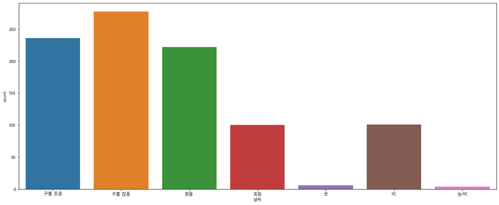

```python
sns.countplot(data=df, x='날씨')
```

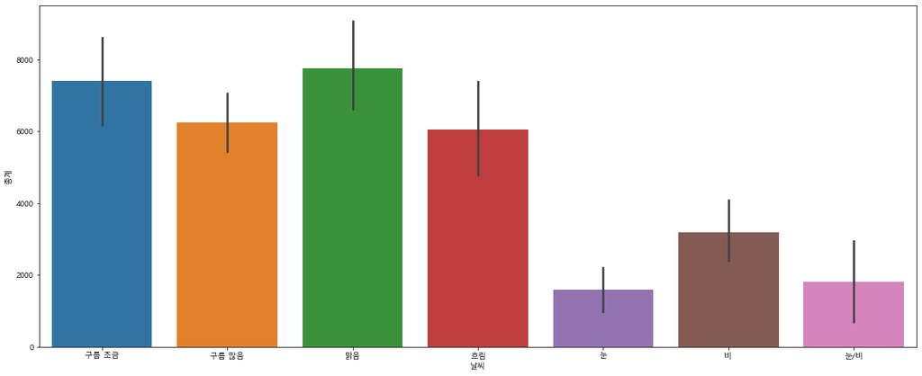

```python
sns.barplot(data=df, x='날씨', y='총계')
```

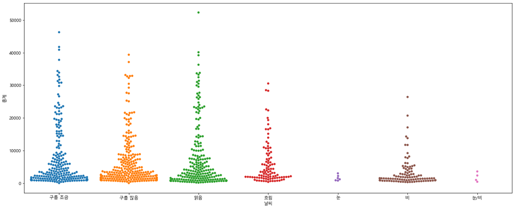

```python
 sns.swarmplot(data=df,x='날씨',y='총계')
```

날씨에 따라서 입장객수 차이가 발생하는 군요.

맑음 > 구름 조금 > 구름 많음 > 흐림 > 비 순으로 평균 입장객 수가 많습니다.

맑음, 구름조금, 구름많음은 사실상 큰 차이가 없습니다.

비나 눈이 오는 날씨와 그렇지 않은 날씨간의 차이가 크군요.

#### [검증 결과]

#### 가설 1) 날씨가 좋으면 입장객수가 늘어난다.

- 날씨가 눈 또는 눈/비 의 경우는 표본이 너무 작기 때문에 분석에서 제외한다.
- 비가 오는 날의 입장객 수는 오지 않는 날의 입장객 수보다 현저히 적다.
- 날씨가 좋으면 입장객수가 늘어난다는 가설은 검증되었다.

#### 가설 2) 나들이 하기 좋은 월의 입장객수가 많다.

나들이하기 좋은 4, 5, 6월과 9,10월의 입장객수가 많을 것으로 예상한다.

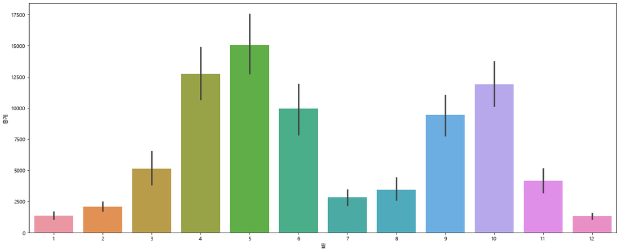

```python
sns.barplot(data=df, x='월', y='총계')
```

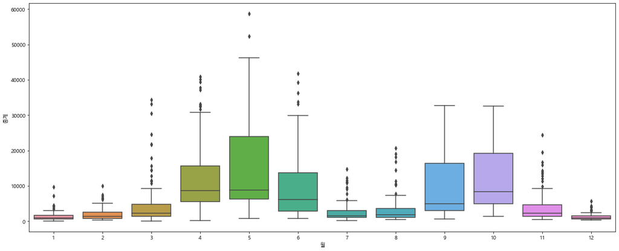

```python
sns.boxplot(data=df, x='월',y='총계')
```

4, 5, 6, 9, 10 월의 입장객 수가 다른 월에 비해 많은 것을 확인 할 수 있습니다.

```python
df.groupby(by='월')['유료합계','어른','청소년','어린이','외국인','단체','무료합계','총계'].mean()
```

| 월 | 유료합계 | 어른 | 청소년 | 어린이 | 외국인 | 단체 | 무료합계 | 총계 |
| --- | --- | --- | --- | --- | --- | --- | --- | --- |
| 1 | 713.892473 | 497.892473 | 136.215054 | 79.784946 | 17.978495 | 144.516129 | 661.365591 | 1375.258065 |
| 2 | 1251.800000 | 978.129412 | 123.117647 | 150.552941 | 41.447059 | 83.364706 | 825.729412 | 2077.529412 |
| 3 | 3569.134021 | 2957.432990 | 209.000000 | 386.350515 | 41.123711 | 193.494845 | 1536.804124 | 5105.938144 |
| 4 | 8788.311111 | 6811.033333 | 816.422222 | 1061.977778 | 104.411111 | 1802.688889 | 3941.666667 | 12729.977778 |
| 5 | 10287.505376 | 7894.301075 | 1270.827957 | 1122.376344 | 149.505376 | 2413.193548 | 4774.967742 | 15062.473118 |
| 6 | 7019.800000 | 5516.033333 | 849.855556 | 653.911111 | 129.033333 | 1528.911111 | 2923.444444 | 9943.244444 |
| 7 | 1937.053763 | 1443.978495 | 286.193548 | 206.881720 | 79.258065 | 471.720430 | 895.795699 | 2832.849462 |
| 8 | 2518.913978 | 1803.784946 | 254.086022 | 461.021505 | 80.870968 | 277.096774 | 931.623656 | 3450.537634 |
| 9 | 6648.455556 | 5506.133333 | 312.577778 | 829.744444 | 94.033333 | 827.266667 | 2790.866667 | 9439.322222 |
| 10 | 8390.569892 | 6377.075269 | 847.602151 | 1165.892473 | 100.440860 | 2148.763441 | 3514.645161 | 11905.215054 |
| 11 | 2761.933333 | 2068.011111 | 354.211111 | 339.711111 | 40.100000 | 602.533333 | 1408.211111 | 4170.144444 |
| 12 | 642.354430 | 489.797468 | 85.658228 | 66.898734 | 18.746835 | 99.898734 | 667.582278 | 1309.936709 |

우리는 월별 입장객 수 데이터를 100% 신뢰할 수 없습니다.

왜냐하면 특정년의 특정요인에 따라 월별 입장객수 변동이 발생할 수도 있기 때문입니다.

따라서 이번에는 연월별 입장객 수를 확인하도록 하겠습니다.

'연' 컬럼과 '월' 컬럼을 문자형으로 바꾸고 합쳐서 '연월' 컬럼을 새로 만듭니다.

```python
df['연월']=df['연'].astype('str')+'-'+df['월'].astype('str')
```

```python
df['연월']
```

```
0       2016-1
1       2016-1
2       2016-1
3       2016-1
4       2016-1
         ...
1081    2019-3
1082    2019-3
1083    2019-3
1084    2019-3
1085    2019-3
Name: 연월, Length: 1086, dtype: object
```

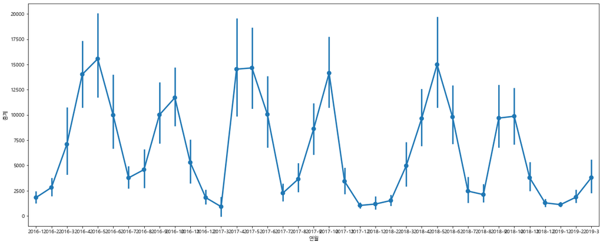

```python
sns.pointplot(data=df, x='연월', y='총계' )
```

X축의 글자가 겹치게 나와서 알아보기 힘들군요

여러가지 그래프 설정 옵션을 알아봅시다.

```python
# 그래프 설정을 위해서 matplotlib 모듈을 불러옵니다.

import matplotlib as mlp
```

※ 그래프 설정 옵션

- plt.figure : 그래프 크기
- plt.title : 그래프 제목
- plt.ylabel : y축 명칭
- plt.xticks : x축 글자 각도
- mlp.rcParams : 글씨 크기

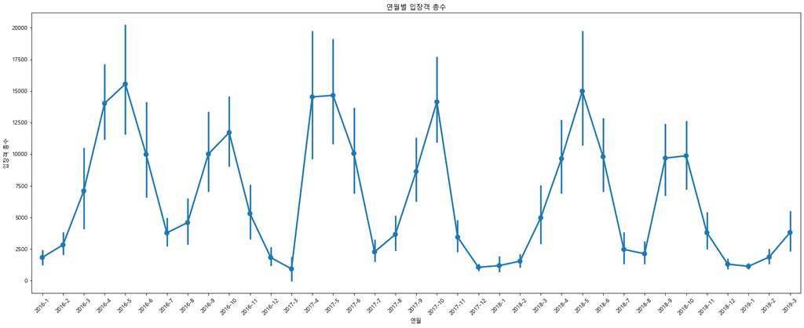

```python
plt.figure(figsize=(24, 9))

sns.pointplot(data=df, x='연월', y='총계' )
plt.title('연월별 입장객 총수')
plt.ylabel('입장객 총수')
plt.xticks(rotation=45)
mlp.rcParams['font.size'] = 20
```

위 그래프를 살펴보면 2017년 1월, 2월의 데이터가 없고 2017년 3월의 데이터가 다른 월에 비해 지나치게 입장객 수가 적은 것을 확인할 수 있습니다.

이유를 살펴보니 2016년 12월 18일부터 2017년 3월 27일까지 조류독감(AI)로 인해 서울대공원 운영을 중단했다고 합니다.

#### [검증 결과]

#### 가설 2) 나들이 하기 좋은 월의 입장객수가 많다.

- 4, 5, 6, 9, 10 월의 입장객수는 다른 월에 비해 많다. 그 중에서도 5월이 가장 많다.
- 나들이 하기 좋은 월의 입장객수가 많다는 가설은 검증되었다.

#### 가설 3) 주말, 공휴일이 평일, 비공휴일보다 입장객 수가 많다

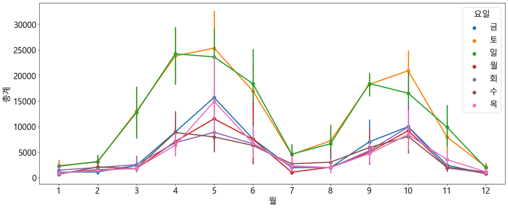

```python
sns.pointplot(data=df, x='월', y='총계', hue='요일' )
```

가정대로 주말의 입장객 수가 평일 입장객 수보다 많습니다.

5월의 경우 요일별 입장객 수 차이가 많습니다. 더 자세히 살펴보죠.

목요일과 금요일의 입장객 수가 다른 평일 요일에 비해 많네요.

어린이날과 대체공휴일, 징검다리 휴일로 평일인데도 불구하고 입장객 수가 많은 것으로 보입니다.

꺽여지는 점마다 막대기가 보이는데요.

이는 분산을 뜻합니다. 평균에 대비하여 얼마나 데이터가 분포되어 있는지를 뜻하지요.

막대기의 길이가 길수로 더 넓게 퍼져있음을 뜻합니다.

다른 월에 비해 5월은 분산 값이 더 큼을 알 수 있습니다.

추측컨데 5월5일 어린이날이 끼어있는 주와 아닌주 간의 입장객수차이가 크기 때문일 것입니다.

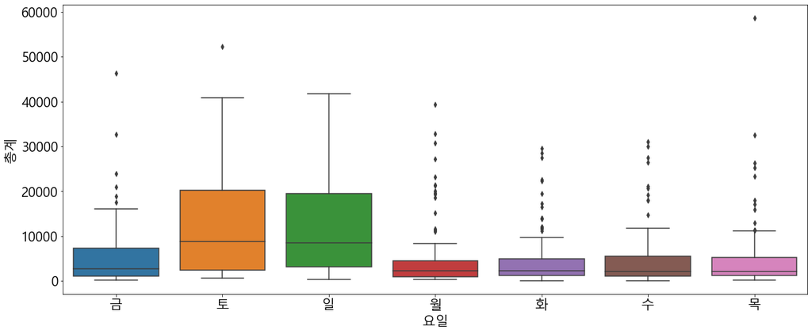

```python
sns.boxplot( data=df, x='요일', y='총계')
```

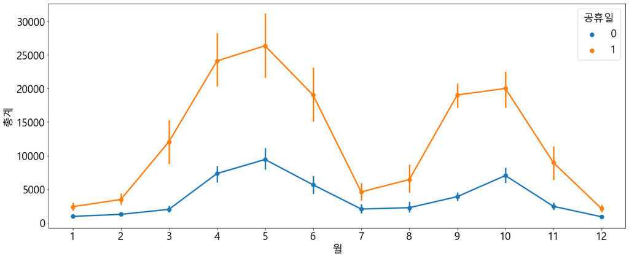

```python
sns.pointplot(data=df, x='월', y='총계', hue='공휴일' )
```

예상대로 공휴일의 입장객 수가 비공휴일의 입장객수보다 많습니다.

여기서도 5월 공휴일의 분산이 큽니다.

어린이날 등의 휴일로 인한 것으로 보입니다.

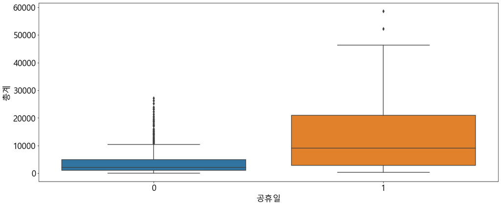

```python
sns.boxplot( data=df, x='공휴일', y='총계')
```

#### [검증 결과]

#### 가설 3) 주말, 공휴일이 평일, 비공휴일보다 입장객 수가 많다

- 주말, 공휴일이 평일, 비공휴일보다 입장객 수가 많을 것이라는 가설은 검증되었다.
- 특이사항으로는 5월의 경우 분산이 크고 평일인데도 불구하고 입장객수가 많은 요일이 있다.

#### 가설 4) 어른, 청소년, 어린이, 외국인, 단체 입장객 별로 입장 패턴이 다를 것이다.

컬럼 데이터 별 입장 패턴을 한 눈에 알아보기 위해서 여러 개의 그래프를 한 화면에 보겠습니다.

4x2(4행2열)의 총 8개의 그래프를 그립니다.

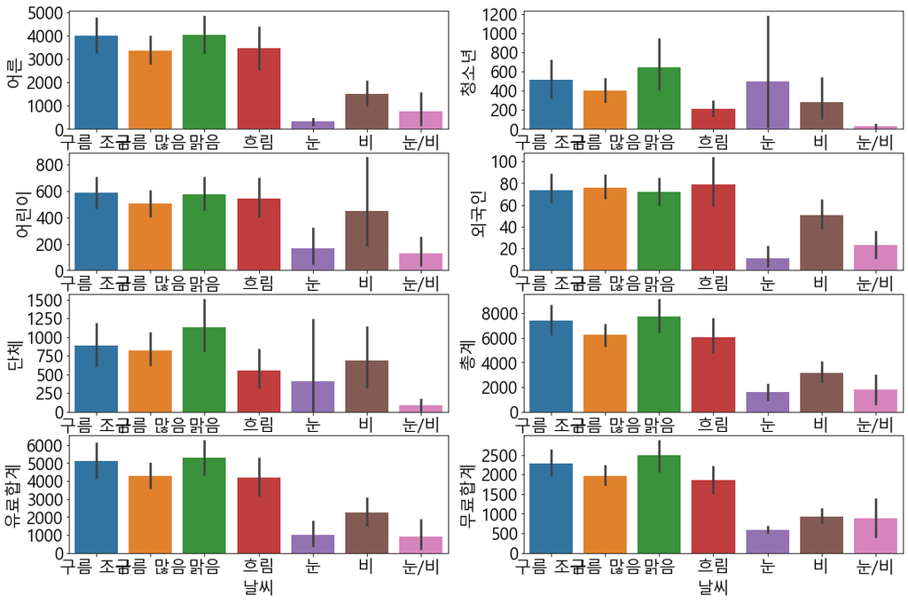

```python
figure, ((ax1, ax2), (ax3, ax4), (ax5, ax6), (ax7, ax8)) = plt.subplots(nrows=4, ncols=2)

figure.set_size_inches(18, 12)

mlp.rcParams['font.size'] = 10

sns.barplot(data=df, x='날씨', y='어른', ax=ax1)
sns.barplot(data=df, x='날씨', y='청소년', ax=ax2)
sns.barplot(data=df, x='날씨', y='어린이', ax=ax3)
sns.barplot(data=df, x='날씨', y='외국인', ax=ax4)
sns.barplot(data=df, x='날씨', y='단체', ax=ax5)
sns.barplot(data=df, x='날씨', y='총계', ax=ax6)
sns.barplot(data=df, x='날씨', y='유료합계', ax=ax7)
sns.barplot(data=df, x='날씨', y='무료합계', ax=ax8)
```

날씨에 따른 각 컬럼별 입장객수를 살펴봅시다.

우리는 이전에 날씨가 맑음, 구름 조금, 구름 많음, 흐림인 경우 눈, 비, 눈/비의 경우보다 입장객 수가 많은 것을 확인하였습니다.

대부분의 데이터에서 이 가설을 따르고 있음을 확인 할 수 있습니다.

그러나 청소년과 단체의 경우에는 날씨별 입장객 수 차이가 크지 않은 것을 확인할 수 있습니다.

왜 그럴까요?

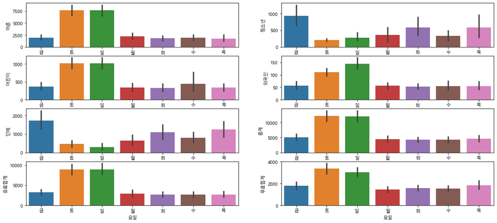

```python
figure, ((ax1, ax2), (ax3, ax4), (ax5, ax6), (ax7, ax8)) = plt.subplots(nrows=4, ncols=2)

figure.set_size_inches(18, 8)

mlp.rcParams['font.size'] = 10

sns.barplot(data=df, x='요일', y='어른', ax=ax1)
sns.barplot(data=df, x='요일', y='청소년', ax=ax2)
sns.barplot(data=df, x='요일', y='어린이', ax=ax3)
sns.barplot(data=df, x='요일', y='외국인', ax=ax4)
sns.barplot(data=df, x='요일', y='단체', ax=ax5)
sns.barplot(data=df, x='요일', y='총계', ax=ax6)
sns.barplot(data=df, x='요일', y='유료합계', ax=ax7)
sns.barplot(data=df, x='요일', y='무료합계', ax=ax8)
```

```python
df.groupby(by='요일')['유료합계','어른','청소년','어린이','외국인','단체','무료합계','총계'].mean()
```

| 요일 | 유료합계 | 어른 | 청소년 | 어린이 | 외국인 | 단체 | 무료합계 | 총계 |
| --- | --- | --- | --- | --- | --- | --- | --- | --- |
| 금 | 3274.653846 | 1964.185897 | 938.371795 | 359.980769 | 56.480769 | 1734.288462 | 1772.833333 | 5047.487179 |
| 목 | 2693.464516 | 1770.696774 | 575.735484 | 343.225806 | 54.354839 | 1236.606452 | 1845.206452 | 4538.670968 |
| 수 | 2671.729032 | 1885.664516 | 329.941935 | 449.329032 | 53.954839 | 800.090323 | 1557.322581 | 4229.051613 |
| 월 | 2925.058442 | 2231.545455 | 352.863636 | 335.694805 | 55.435065 | 636.603896 | 1444.214286 | 4369.272727 |
| 일 | 8974.174194 | 7669.587097 | 275.470968 | 1018.664516 | 144.541935 | 285.722581 | 3043.361290 | 12017.535484 |
| 토 | 8878.192308 | 7631.698718 | 210.653846 | 1010.307692 | 110.051282 | 456.608974 | 3365.314103 | 12243.506410 |
| 화 | 2722.406452 | 1801.683871 | 585.432258 | 331.496774 | 52.748387 | 1095.632258 | 1594.135484 | 4316.541935 |

이번에는 요일별 각 컬럼별 입장객수를 살펴봅시다.

우리는 이전 분석에서 평일이 주말보다 입장객 수가 적은 것을 확인하였습니다.

대부분의 데이터에서 이 가설을 따르고 있음을 확인 할 수 있습니다.

그러나 청소년의 경우 오히려 주말의 입장객 수가 가장 적고 금요일이 가장 많습니다.

단체의 경우에도 오히려 주말의 입장객 수가 가장 적고 금요일이 가장 많습니다.

생각해보면 청소년과 단체의 입장객 수는 행사 일정에 따라 결정되는 경우가 많습니다.

그렇기 때문에 주말보다는 평일에 입장객 수가 많은 것이겠지요.

날씨가 좋지 않음에도 입장객 수가 많은 것도 똑같은 이유입니다.

#### [검증 결과]

#### 가설 4) 어른, 청소년, 어린이, 외국인, 단체 입장객 별로 입장 패턴이 다를 것이다.

- 어른, 어린이, 외국인은 주말이 평일보다 입장객 수가 많습니다. 날씨가 좋은 날이 좋지 않은 날보다도 입장객수가 많다.
- 반면, 청소년, 단체의 경우에는 오히려 평일의 입장객 수가 많습니다. 날씨가 좋지 않은 때에도 입장객 수가 많다.

이제 날짜나 날씨 요인 외에도 입장객 수에 영향을 미치는 다른 요인이 있지 않을까 하는 생각을 해봅시다.

최근 문제가 심각한 미세먼지는 어떨까요?

과연 미세먼지가 심한 날에는 입장객수가 급감할까요?

서울대공원 입장객수와 마찬가지로 미세먼지 데이터를 가지고 와봅시다.

미세먼지 데이터는 아래 링크에서 확인 가능합니다

http://cleanair.seoul.go.kr/air_pollution.htm?method=period

```python
ms=pd.read_csv('data/MiseMunji.csv')
ms.head()
```

|  | 날짜 | 미세먼지 | 초미세먼지 | 오존 | 이산화질소 | 일산화탄소 | 아황산가스 |
| --- | --- | --- | --- | --- | --- | --- | --- |
| 0 | 20160101 | 68 | 45 | 0.006 | 0.047 | 1.0 | 0.006 |
| 1 | 20160102 | 51 | 31 | 0.009 | 0.044 | 0.7 | 0.006 |
| 2 | 20160103 | 96 | 58 | 0.013 | 0.049 | 0.9 | 0.007 |
| 3 | 20160104 | 74 | 47 | 0.025 | 0.025 | 0.6 | 0.006 |
| 4 | 20160105 | 32 | 16 | 0.016 | 0.025 | 0.4 | 0.006 |

```python
ms.shape
```

```
(1186, 7)
```

1186행과 7열로 구성되어 있습니다.

```python
ms.info()
```

```
<class 'pandas.core.frame.DataFrame'>
RangeIndex: 1186 entries, 0 to 1185
Data columns (total 7 columns):
 #   Column  Non-Null Count  Dtype
---  ------  --------------  -----
 0   날짜      1186 non-null   int64
 1   미세먼지    1186 non-null   int64
 2   초미세먼지   1186 non-null   int64
 3   오존      1186 non-null   float64
 4   이산화질소   1186 non-null   float64
 5   일산화탄소   1186 non-null   float64
 6   아황산가스   1186 non-null   float64
dtypes: float64(4), int64(3)
memory usage: 65.0 KB
```

모든 데이터가 숫자형이군요.

날짜 컬럼 데이터의 형태를 날짜(datetime)로 바꿔봅시다.

```python
ms['날짜']=pd.to_datetime(ms['날짜'])
ms.head()
```

|  | 날짜 | 미세먼지 | 초미세먼지 | 오존 | 이산화질소 | 일산화탄소 | 아황산가스 |
| --- | --- | --- | --- | --- | --- | --- | --- |
| 0 | 1970-01-01 00:00:00.020160101 | 68 | 45 | 0.006 | 0.047 | 1.0 | 0.006 |
| 1 | 1970-01-01 00:00:00.020160102 | 51 | 31 | 0.009 | 0.044 | 0.7 | 0.006 |
| 2 | 1970-01-01 00:00:00.020160103 | 96 | 58 | 0.013 | 0.049 | 0.9 | 0.007 |
| 3 | 1970-01-01 00:00:00.020160104 | 74 | 47 | 0.025 | 0.025 | 0.6 | 0.006 |
| 4 | 1970-01-01 00:00:00.020160105 | 32 | 16 | 0.016 | 0.025 | 0.4 | 0.006 |

변환이 이상하게 되었네요.

2016-01-01 과 같이 기본 형태가 아니기 때문입니다.

포맷 설정을 활용해봅시다.

```python
ms=pd.read_csv('data/MiseMunji.csv')
ms['날짜']=pd.to_datetime(ms['날짜'], format='%Y%m%d')
ms.head()
```

|  | 날짜 | 미세먼지 | 초미세먼지 | 오존 | 이산화질소 | 일산화탄소 | 아황산가스 |
| --- | --- | --- | --- | --- | --- | --- | --- |
| 0 | 2016-01-01 | 68 | 45 | 0.006 | 0.047 | 1.0 | 0.006 |
| 1 | 2016-01-02 | 51 | 31 | 0.009 | 0.044 | 0.7 | 0.006 |
| 2 | 2016-01-03 | 96 | 58 | 0.013 | 0.049 | 0.9 | 0.007 |
| 3 | 2016-01-04 | 74 | 47 | 0.025 | 0.025 | 0.6 | 0.006 |
| 4 | 2016-01-05 | 32 | 16 | 0.016 | 0.025 | 0.4 | 0.006 |

```python
ms.dtypes
```

```
날짜       datetime64[ns]
미세먼지              int64
초미세먼지             int64
오존              float64
이산화질소           float64
일산화탄소           float64
아황산가스           float64
dtype: object
```

잘 되었군요.

이제 서울대공원 입장객 데이터와 미세먼지 데이터를 합쳐보겠습니다.

두 데이터프레임이 공통으로 가지고 있는 '날짜'컬럼을 기준으로 합쳐보도록 하겠습니다.

```python
df.shape
```

```
(1086, 17)
```

```python
ms.shape
```

```
(1186, 7)
```

서울대공원 입장객 데이터 행의 갯수가 미세먼지 데이터 열의 갯수보다 더 적네요.

위에서 말했듯이 조류독감으로 인해 2016년 12월 18일부터 2017년 3월 27일까지 서울대공원 운영을 중단했기 때문에 그 날짜의 데이터가 빠져있는 것입니다.

merge() 함수를 사용하여 합치되 서울대공원 데이터를 기준으로 합쳐야 합니다.

따라서 how를 left로 설정하겠습니다.

```python
dm=pd.merge(df, ms, how='left',on='날짜')
dm.head()
```

|  | 날짜 | 요일 | 공휴일 | 날씨 | 유료합계 | 어른 | 청소년 | 어린이 | 외국인 | 단체 | ... | 월 | 일 | 요일(num) | 연월 | 미세먼지 | 초미세먼지 | 오존 | 이산화질소 | 일산화탄소 | 아황산가스 |
| --- | --- | --- | --- | --- | --- | --- | --- | --- | --- | --- | --- | --- | --- | --- | --- | --- | --- | --- | --- | --- | --- |
| 0 | 2016-01-01 | 금 | 1 | 구름 조금 | 3359 | 2799 | 141.0 | 419 | 47.0 | 0.0 | ... | 1 | 1 | 4 | 2016-1 | 68 | 45 | 0.006 | 0.047 | 1.0 | 0.006 |
| 1 | 2016-01-02 | 토 | 1 | 구름 많음 | 5173 | 4370 | 203.0 | 600 | 100.0 | 111.0 | ... | 1 | 2 | 5 | 2016-1 | 51 | 31 | 0.009 | 0.044 | 0.7 | 0.006 |
| 2 | 2016-01-03 | 일 | 1 | 구름 많음 | 3008 | 2571 | 128.0 | 309 | 91.0 | 0.0 | ... | 1 | 3 | 6 | 2016-1 | 96 | 58 | 0.013 | 0.049 | 0.9 | 0.007 |
| 3 | 2016-01-04 | 월 | 0 | 구름 많음 | 890 | 602 | 53.0 | 235 | 51.0 | 223.0 | ... | 1 | 4 | 0 | 2016-1 | 74 | 47 | 0.025 | 0.025 | 0.6 | 0.006 |
| 4 | 2016-01-05 | 화 | 0 | 구름 많음 | 416 | 319 | 35.0 | 62 | 43.0 | 47.0 | ... | 1 | 5 | 1 | 2016-1 | 32 | 16 | 0.016 | 0.025 | 0.4 | 0.006 |

5 rows × 23 columns

```python
dm.shape
```

```
(1086, 23)
```

두 데이터프레임이 합쳐져 하나의 데이터프레임으로 만들어졌습니다.

#### 가설 5) 미세먼지 지수가 높을 수록 입장객수는 적을 것이다.

시각화를 통해 위의 가정을 검증해보겠습니다.

우선 미세먼지 컬럼을 분석해봅시다

```python
dm[['미세먼지', '초미세먼지']].describe()
```

|  | 미세먼지 | 초미세먼지 |
| --- | --- | --- |
| count | 1086.000000 | 1086.000000 |
| mean | 44.754144 | 25.030387 |
| std | 24.618777 | 15.267688 |
| min | 6.000000 | 3.000000 |
| 25% | 29.000000 | 15.000000 |
| 50% | 41.000000 | 22.000000 |
| 75% | 56.000000 | 31.000000 |
| max | 198.000000 | 135.000000 |

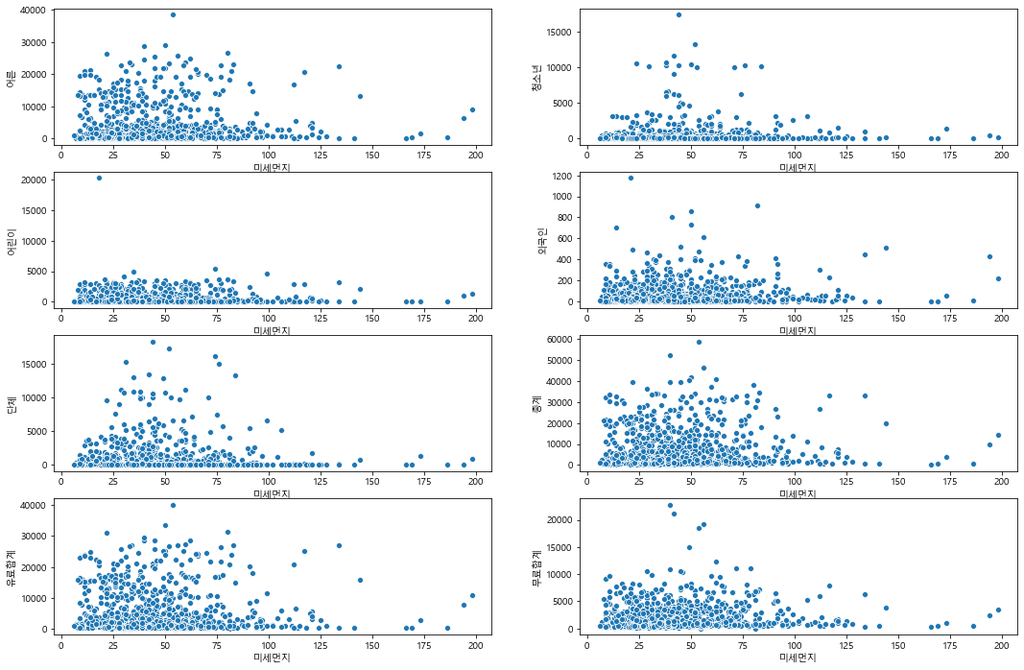

```python
figure, ((ax1, ax2), (ax3, ax4), (ax5, ax6), (ax7, ax8)) = plt.subplots(nrows=4, ncols=2)

figure.set_size_inches(18, 12)

sns.scatterplot(data=dm, x='미세먼지', y='어른', ax=ax1)
sns.scatterplot(data=dm, x='미세먼지', y='청소년', ax=ax2)
sns.scatterplot(data=dm, x='미세먼지', y='어린이', ax=ax3)
sns.scatterplot(data=dm, x='미세먼지', y='외국인', ax=ax4)
sns.scatterplot(data=dm, x='미세먼지', y='단체', ax=ax5)
sns.scatterplot(data=dm, x='미세먼지', y='총계', ax=ax6)
sns.scatterplot(data=dm, x='미세먼지', y='유료합계', ax=ax7)
sns.scatterplot(data=dm, x='미세먼지', y='무료합계', ax=ax8)
```

```python
dm.corr()['미세먼지']
```

```
공휴일        0.001538
유료합계       0.022831
어른         0.018634
청소년        0.033687
어린이       -0.015219
외국인        0.043977
단체         0.029319
무료합계       0.029923
총계         0.025540
연          0.021212
월         -0.294244
일          0.055314
요일(num)   -0.003980
미세먼지       1.000000
초미세먼지      0.848723
오존         0.041157
이산화질소      0.572558
일산화탄소      0.644509
아황산가스      0.584641
Name: 미세먼지, dtype: float64
```

### 미세먼지 지수는 입장객수와 상관관계가 거의 없습니다....

무언가 잘못 분석하지 않았을까요?

미세먼지를 정규화시키면 좀 더 정확한 분석을 할 수 있지 않을까요?

### 1) 정규화 시켜보기

우선 커널밀도 그래프를 그려봅니다.

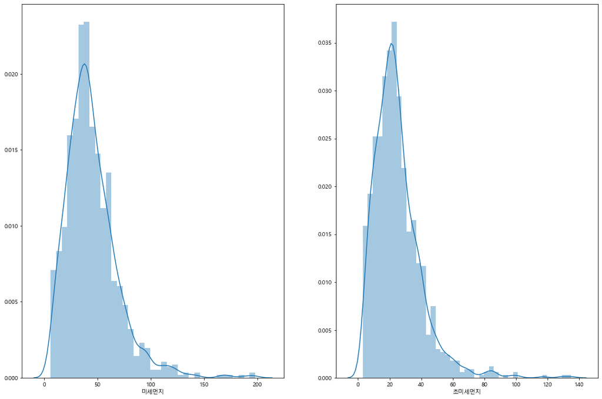

```python
figure, ((ax1, ax2)) = plt.subplots(nrows=1, ncols=2)

figure.set_size_inches(18, 12)

sns.distplot(dm['미세먼지'], ax=ax1)
sns.distplot(dm['초미세먼지'], ax=ax2)
```

왼쪽으로 치우친 분포를 보이는 군요.

로그를 씌워서 정규화 시켜봅시다.

```python
import numpy as np
```

```python
dm['미세먼지_log']=np.log1p(dm['미세먼지'])
dm['초미세먼지_log']=np.log1p(dm['초미세먼지'])
```

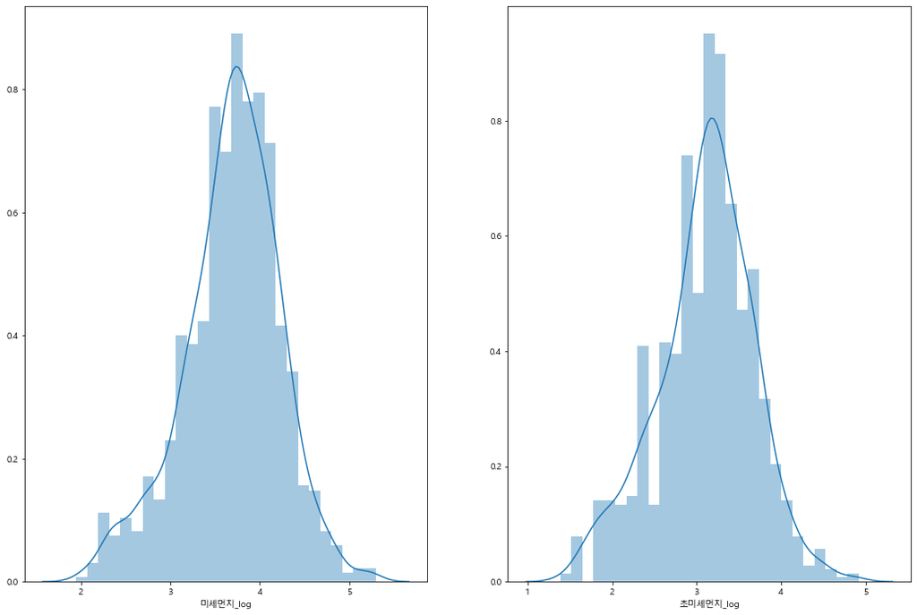

```python
figure, ((ax1, ax2)) = plt.subplots(nrows=1, ncols=2)

figure.set_size_inches(18, 12)

sns.distplot(dm['미세먼지_log'], ax=ax1)
sns.distplot(dm['초미세먼지_log'], ax=ax2)
```

이번에는 미세먼지와 입장객수 간의 관계를 살펴보겠습니다.

입장객과 관련한 컬럼 데이터도 모두 로그를 씌워서 정규화시키겠습니다.

```python
dm['총계_log']=np.log1p(dm['총계'])
dm['어른_log']=np.log1p(dm['어른'])
dm['어린이_log']=np.log1p(dm['어린이'])
dm['청소년_log']=np.log1p(dm['청소년'])
dm['단체_log']=np.log1p(dm['총계'])
dm['외국인_log']=np.log1p(dm['외국인'])
dm['유료합계_log']=np.log1p(dm['유료합계'])
dm['무료합계_log']=np.log1p(dm['무료합계'])
```

```python
dm.columns
```

```
Index(['날짜', '요일', '공휴일', '날씨', '유료합계', '어른', '청소년', '어린이', '외국인', '단체',
       '무료합계', '총계', '연', '월', '일', '요일(num)', '연월', '미세먼지', '초미세먼지', '오존',
       '이산화질소', '일산화탄소', '아황산가스', '미세먼지_log', '초미세먼지_log', '총계_log', '어른_log',
       '어린이_log', '청소년_log', '단체_log', '외국인_log', '유료합계_log', '무료합계_log'],
      dtype='object')
```

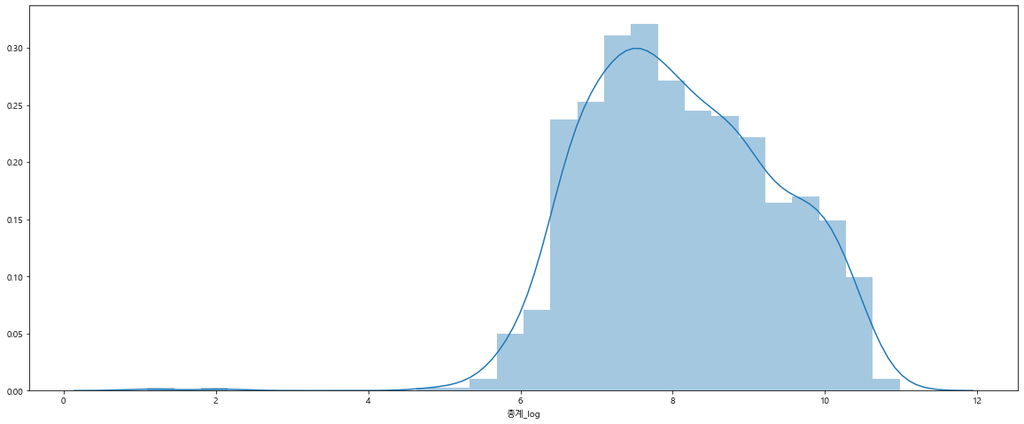

```python
sns.distplot(dm['총계_log'])
```

로그화시킨 컬럼을 따로 뽑아서 dm_log에 저장합니다.

```python
dm_log=dm[['날짜', '요일', '공휴일', '날씨', '연', '월', '일', '요일(num)', '연월',
           '미세먼지_log', '초미세먼지_log', '총계_log', '어른_log', '어린이_log',
           '청소년_log', '단체_log', '외국인_log', '유료합계_log', '무료합계_log']]
```

```python
dm_log.corr()['미세먼지_log']
```

```
공휴일         -0.024162
연           -0.032927
월           -0.298194
일            0.063251
요일(num)     -0.006029
미세먼지_log     1.000000
초미세먼지_log    0.912045
총계_log       0.018458
어른_log       0.009799
어린이_log     -0.034872
청소년_log      0.040051
단체_log       0.018458
외국인_log     -0.014078
유료합계_log    -0.001355
무료합계_log     0.056736
Name: 미세먼지_log, dtype: float64
```

로그로 정규화시켜도 미세먼지/초미세먼지와 입장객수는 상관관계가 없습니다.

상관관계가 거의 없는 것을 수치로도 확인 할 수 있습니다.

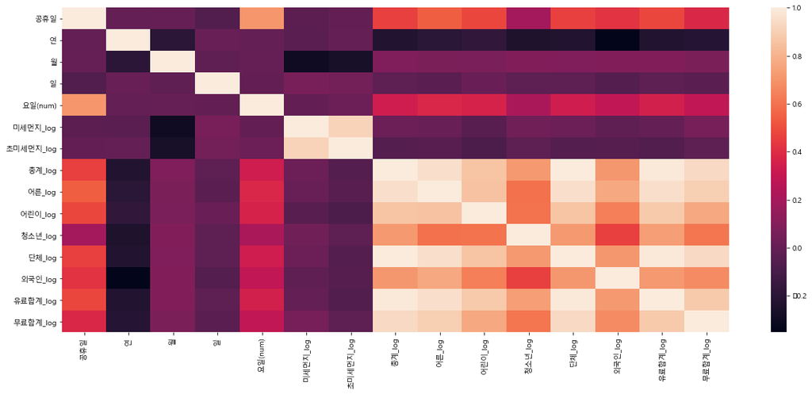

```python
sns.heatmap(dm_log.corr())
```

히트맵으로도 상관관계를 확인 할 수 있습니다.

#### 미세먼지는 입장객수와 무관한 것일까요?

#### 사람들은 미세먼지 지수가 아닌 미세먼지 경보에 따라 서울대공원 입장여부를 판단하지 않을까요?

### 2) 미세먼지 경보에 따른 입장객수 살펴보기

공식적인 미세먼지 경보 기준은 다음과 같습니다.

- 0 ~ 30 : 좋음
- 31 ~ 80 : 보통
- 81 ~ 150 : 나쁨
- 151 ~ : 매우 나쁨

미세먼지경보 컬럼을 생성하여 미세먼지 경보 기준에 따라 데이터를 넣습니다.

```python
def mm(a):
    if a<=30:
        return 0
    elif a<=80:
        return 1
    elif a<=150:
        return 2
    else:
        return 3
```

```python
dm['미세먼지경보']=dm['미세먼지'].apply(lambda e : mm(e))
```

```python
dm[['미세먼지경보','미세먼지']].head(10)
```

|  | 미세먼지경보 | 미세먼지 |
| --- | --- | --- |
| 0 | 1 | 68 |
| 1 | 1 | 51 |
| 2 | 2 | 96 |
| 3 | 1 | 74 |
| 4 | 1 | 32 |
| 5 | 1 | 56 |
| 6 | 1 | 39 |
| 7 | 1 | 34 |
| 8 | 1 | 37 |
| 9 | 1 | 32 |

```python
dm['미세먼지경보'].value_counts()
```

```
1    700
0    307
2     73
3      6
Name: 미세먼지경보, dtype: int64
```

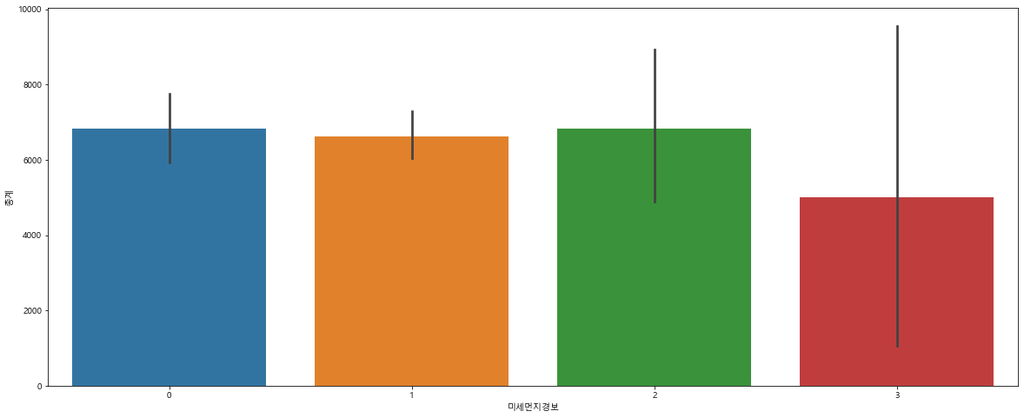

```python
sns.barplot(data=dm, x='미세먼지경보',y='총계')
```

미세먼지 경보가 3(매우 나쁨)일때는 입장객수가 줄어든것을 확인 할 수 있습니다.

하지만 미세먼지 경보가 0, 1, 2일 때에는 입장객수 차이가 거의 발생하지 않네요.

또 미세먼지 경보가 3인 데이터는 6개 밖에 없습니다. 따라서 신뢰성에 의심이 갈 수 밖에 없네요

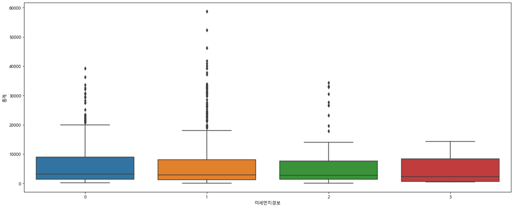

```python
sns.boxplot(data=dm, x='미세먼지경보',y='총계')
```

이상치가 상당히 많네요. 아무래도 1) 공휴일 여부와 2) 날씨에 따른 입장객수 차이가 크기 때문으로 생각됩니다.

따라서 이를 반영하여 분석을 진행해보겠습니다.

### 3) 날씨와 공휴일 영향을 최소화시킨다.

- 날씨 데이터 중 비, 눈, 눈/비 인 경우를 제외합니다.
- 공휴일 컬럼 데이터값이 1인 경우만 추출합니다.(공휴일, 주말인 데이터만 추출합니다.)

```python
dm_weho=dm[((dm['날씨']=='구름 많음') | (dm['날씨']=='구름 조금') | (dm['날씨']=='맑음') | (dm['날씨']=='흐림'))&(dm['공휴일']==1)]
dm_weho.head()
```

|  | 날짜 | 요일 | 공휴일 | 날씨 | 유료합계 | 어른 | 청소년 | 어린이 | 외국인 | 단체 | ... | 초미세먼지_log | 총계_log | 어른_log | 어린이_log | 청소년_log | 단체_log | 외국인_log | 유료합계_log | 무료합계_log | 미세먼지경보 |
| --- | --- | --- | --- | --- | --- | --- | --- | --- | --- | --- | --- | --- | --- | --- | --- | --- | --- | --- | --- | --- | --- |
| 0 | 2016-01-01 | 금 | 1 | 구름 조금 | 3359 | 2799 | 141.0 | 419 | 47.0 | 0.0 | ... | 3.828641 | 8.385489 | 7.937375 | 6.040255 | 4.955827 | 8.385489 | 3.871201 | 8.119696 | 6.931472 | 1 |
| 1 | 2016-01-02 | 토 | 1 | 구름 많음 | 5173 | 4370 | 203.0 | 600 | 100.0 | 111.0 | ... | 3.465736 | 8.890961 | 8.382747 | 6.398595 | 5.318120 | 8.890961 | 4.615121 | 8.551401 | 7.646354 | 1 |
| 2 | 2016-01-03 | 일 | 1 | 구름 많음 | 3008 | 2571 | 128.0 | 309 | 91.0 | 0.0 | ... | 4.077537 | 8.424639 | 7.852439 | 5.736572 | 4.859812 | 8.424639 | 4.521789 | 8.009363 | 7.346010 | 2 |
| 8 | 2016-01-09 | 토 | 1 | 구름 많음 | 1418 | 1227 | 78.0 | 113 | 47.0 | 80.0 | ... | 2.995732 | 7.878913 | 7.113142 | 4.736198 | 4.369448 | 7.878913 | 3.871201 | 7.257708 | 7.109062 | 1 |
| 9 | 2016-01-10 | 일 | 1 | 구름 많음 | 2211 | 1839 | 96.0 | 276 | 34.0 | 61.0 | ... | 2.995732 | 8.190077 | 7.517521 | 5.624018 | 4.574711 | 8.190077 | 3.555348 | 7.701652 | 7.239933 | 1 |

5 rows × 34 columns

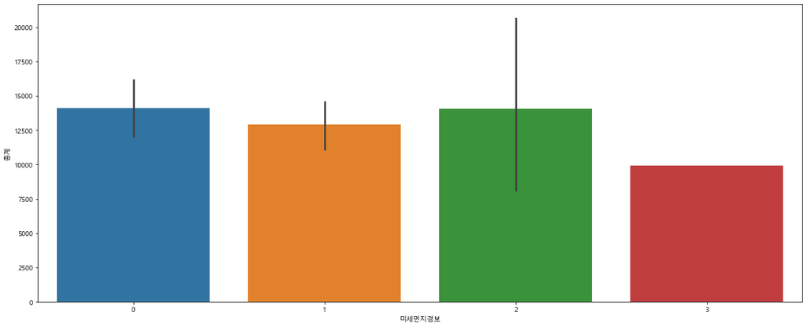

```python
sns.barplot(data=dm_weho, x='미세먼지경보', y='총계')
```

미세먼지 경보 별 입장객 평균은 비슷합니다.

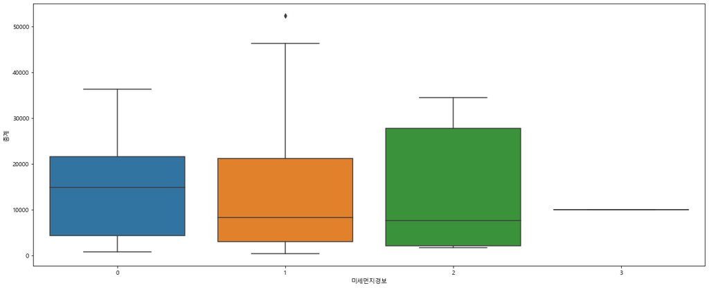

```python
sns.boxplot(data=dm_weho, x='미세먼지경보', y='총계')
```

미세먼지 경보가 보통(1), 나쁨(2)일 때 중앙값이 미세먼지 경보가 좋음(0)일 때보다 낮은 것으로 나오네요.

혹시 미세먼지 경보가 보통(1), 나쁨(2) 인데도 불구하고 4,5월의 입장객수가 많은 날들로 인해 미세먼지경보 별 입장객수 평균이 비숫한 것으로 나온건 아닐까요?

우선 월별로 미세먼지지수의 분포를 살펴봅시다.

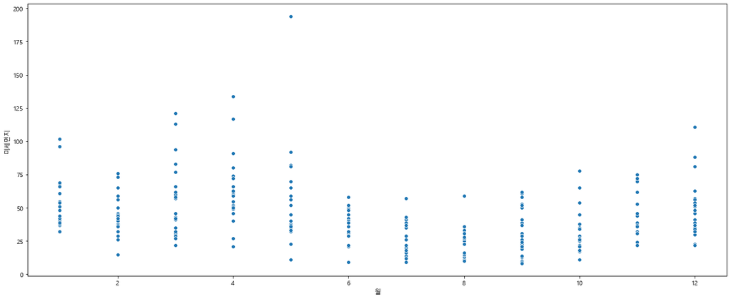

```python
sns.scatterplot(data=dm_weho, x='월', y='미세먼지')
```

다른 월에 비해 대체적으로 1월, 3월, 4월, 5월, 12월의 미세먼지 지수가 높네요

우리는 이전 가설에서 4월, 5월의 평균 입장객수가 다른 월에 비해 많음을 확인했습니다.

그렇다면 3월, 4월, 5월의 미세먼지 경보가 보통 또는 나쁨인데도 불구하고 입장객수가 많은 날들로 인해 미세먼지 경보별 평균 입장객수를 높인건 아닐까요?

```python
dm_weho345=dm_weho[(dm_weho['월']==3) | (dm_weho['월']==4) | (dm_weho['월']==5)]
```

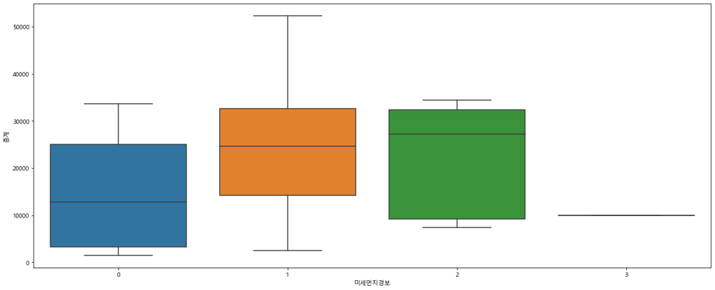

```python
sns.boxplot(data=dm_weho345, x='미세먼지경보', y='총계')
```

오히려 미세먼지지수 경보가 나쁠수록 입장객수가 늘어나는 것처럼 보입니다.

혹시 4월의 벚꽃축제기간이나 5월의 어린이날 기간과 같은 미세먼지경보와 무관하게 입장객수가 많은 날들 때문으로 보입니다.

이번에는 3,4,5월을 제외한 월들을 살펴보겠습니다.

```python
dm_whnot345=dm_weho[(dm_weho['월']!=3) & (dm_weho['월']!=4) & (dm_weho['월']!=5)]
```

```python
dm_whnot345.tail()
```

|  | 날짜 | 요일 | 공휴일 | 날씨 | 유료합계 | 어른 | 청소년 | 어린이 | 외국인 | 단체 | ... | 초미세먼지_log | 총계_log | 어른_log | 어린이_log | 청소년_log | 단체_log | 외국인_log | 유료합계_log | 무료합계_log | 미세먼지경보 |
| --- | --- | --- | --- | --- | --- | --- | --- | --- | --- | --- | --- | --- | --- | --- | --- | --- | --- | --- | --- | --- | --- |
| 1035 | 2019-02-09 | 토 | 1 | 맑음 | 910 | 745 | 40.0 | 125 | 21.0 | 63.0 | ... | 2.890372 | 7.479864 | 6.614726 | 4.836282 | 3.713572 | 7.479864 | 3.091042 | 6.814543 | 6.759255 | 1 |
| 1036 | 2019-02-10 | 일 | 1 | 구름 많음 | 849 | 702 | 54.0 | 93 | 44.0 | 0.0 | ... | 3.178054 | 7.410347 | 6.555357 | 4.543295 | 4.007333 | 7.410347 | 3.806662 | 6.745236 | 6.689599 | 1 |
| 1042 | 2019-02-16 | 토 | 1 | 맑음 | 987 | 810 | 47.0 | 130 | 22.0 | 0.0 | ... | 3.891820 | 7.544332 | 6.698268 | 4.875197 | 3.871201 | 7.544332 | 3.135494 | 6.895683 | 6.805723 | 1 |
| 1043 | 2019-02-17 | 일 | 1 | 맑음 | 1788 | 1507 | 44.0 | 237 | 50.0 | 0.0 | ... | 3.258097 | 7.949797 | 7.318540 | 5.472271 | 3.806662 | 7.949797 | 3.931826 | 7.489412 | 6.953684 | 1 |
| 1049 | 2019-02-23 | 토 | 1 | 맑음 | 2638 | 2259 | 88.0 | 291 | 26.0 | 2.0 | ... | 3.688879 | 8.315566 | 7.723120 | 5.676754 | 4.488636 | 8.315566 | 3.295837 | 7.878155 | 7.278629 | 1 |

5 rows × 34 columns

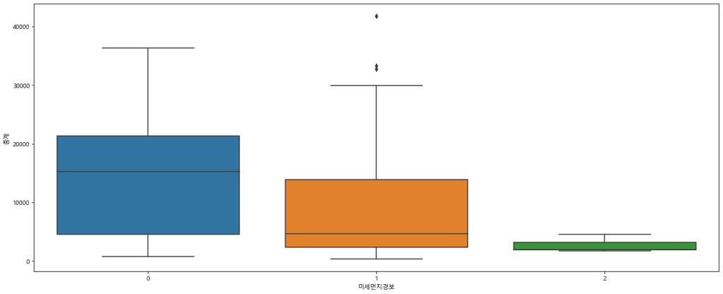

```python
sns.boxplot(data=dm_whnot345, x='미세먼지경보', y='총계')
```

미세먼지 경보가 나쁠수록 입장객 수가 적어짐을 확인할 수 있네요.

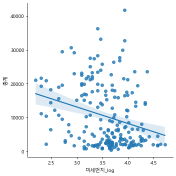

```python
sns.lmplot(data=dm_whnot345, x='미세먼지_log', y='총계')
```

```python
dm_whnot345.corr()['미세먼지경보']
```

```
공휴일               NaN
유료합계        -0.327063
어른          -0.323046
청소년         -0.239217
어린이         -0.353690
외국인         -0.120766
단체          -0.099503
무료합계        -0.287694
총계          -0.319884
연           -0.034163
월           -0.210416
일           -0.024339
요일(num)      0.094056
미세먼지         0.819544
초미세먼지        0.778372
오존          -0.271125
이산화질소        0.642142
일산화탄소        0.682897
아황산가스        0.608565
미세먼지_log     0.836835
초미세먼지_log    0.805438
총계_log      -0.308794
어른_log      -0.314669
어린이_log     -0.322947
청소년_log     -0.249814
단체_log      -0.308794
외국인_log     -0.259951
유료합계_log    -0.316567
무료합계_log    -0.268296
미세먼지경보       1.000000
Name: 미세먼지경보, dtype: float64
```

상관관계도 -0.319884 이 나오는 것으로 보아 어느정도 상관성이 있는것을 확인할 수 있습니다.

어른과 어린이 입장객수는 각각 -0.323046, -0.353690 로 상관관계가 더 있는 것으로 나오네요.

```python
dm_whnot345.corr()[['미세먼지경보','미세먼지','미세먼지_log']]
```

|  | 미세먼지경보 | 미세먼지 | 미세먼지_log |
| --- | --- | --- | --- |
| 공휴일 | NaN | NaN | NaN |
| 유료합계 | -0.327063 | -0.274165 | -0.282932 |
| 어른 | -0.323046 | -0.273704 | -0.282204 |
| 청소년 | -0.239217 | -0.175170 | -0.174191 |
| 어린이 | -0.353690 | -0.280496 | -0.292564 |
| 외국인 | -0.120766 | -0.109587 | -0.091995 |
| 단체 | -0.099503 | -0.024157 | -0.020997 |
| 무료합계 | -0.287694 | -0.232732 | -0.234971 |
| 총계 | -0.319884 | -0.266113 | -0.273367 |
| 연 | -0.034163 | -0.030500 | -0.055387 |
| 월 | -0.210416 | -0.197017 | -0.193464 |
| 일 | -0.024339 | -0.006730 | -0.023217 |
| 요일(num) | 0.094056 | 0.054726 | 0.058354 |
| 미세먼지 | 0.819544 | 1.000000 | 0.946068 |
| 초미세먼지 | 0.778372 | 0.935578 | 0.871549 |
| 오존 | -0.271125 | -0.285975 | -0.245726 |
| 이산화질소 | 0.642142 | 0.696622 | 0.682003 |
| 일산화탄소 | 0.682897 | 0.779206 | 0.737039 |
| 아황산가스 | 0.608565 | 0.648235 | 0.651295 |
| 미세먼지_log | 0.836835 | 0.946068 | 1.000000 |
| 초미세먼지_log | 0.805438 | 0.890814 | 0.933436 |
| 총계_log | -0.308794 | -0.251806 | -0.273395 |
| 어른_log | -0.314669 | -0.256941 | -0.279167 |
| 어린이_log | -0.322947 | -0.252227 | -0.275859 |
| 청소년_log | -0.249814 | -0.182181 | -0.202896 |
| 단체_log | -0.308794 | -0.251806 | -0.273395 |
| 외국인_log | -0.259951 | -0.262765 | -0.238820 |
| 유료합계_log | -0.316567 | -0.257183 | -0.279427 |
| 무료합계_log | -0.268296 | -0.215062 | -0.234223 |
| 미세먼지경보 | 1.000000 | 0.819544 | 0.836835 |

미세먼지지수도 어느 정도 음의 상관관계를 보이나 미세먼지경보보다는 상관관계가 낮습니다.

#### 결론 5) 미세먼지 지수가 높을 수록 입장객수는 적다.

- 입장객수는 단순히 지수의 정도보다 경보 수준에 영향을 더 많이 받는다.
- 미세먼지 경보가 보통, 나쁨 인 경우 평균 입장객수가 비슷한 것으로 나오나, 이는 3, 4, 5월에 미세먼지지수와 무관하게 입장객이 많은 날들 때문에 발생한 것이기 때문에 미세먼지와 입장객수는 무관하는 결론을 내려서는 안된다.
- 3, 4, 5월을 제외한 나머지 월을 살펴보면 미세먼지지수(특히, 경보)가 높으면 입장객수가 줄어듬을 확인할 수 있다.

### 검증결과

#### 가설 1) 날씨가 좋으면 입장객수가 늘어난다.

- 날씨가 눈 또는 눈/비 의 경우는 표본이 너무 작기 때문에 분석에서 제외한다.
- 비가 오는 날의 입장객 수는 오지 않는 날의 입장객 수보다 현저히 적다.
- 날씨가 좋으면 입장객수가 늘어난다는 검증되었다.

#### 가설 2) 나들이 하기 좋은 월의 입장객수가 많다.

- 4, 5, 6, 9, 10 월의 입장객수는 다른 월에 비해 많다. 그 중에서도 5월이 가장 많다.

#### 가설 3) 주말, 공휴일이 평일, 비공휴일보다 입장객 수가 많다

- 주말, 공휴일이 평일, 비공휴일보다 입장객 수가 많을 것이라는 가설은 검증되었습니다.
- 특이사항으로는 5월의 경우 분산이 크고 평일인데도 불구하고 입장객수가 많은 요일이 있습니다.

#### 가설 4) 어른, 청소년, 어린이, 외국인, 단체 입장객 별로 입장 패턴이 다를 것이다.

- 어른, 어린이, 외국인은 주말이 평일보다 입장객 수가 많습니다. 날씨가 좋은 날이 좋지 않은 날보다도 입장객수가 많다.
- 반면, 청소년, 단체의 경우에는 오히려 평일의 입장객 수가 많습니다. 날씨가 좋지 않은 때에도 입장객 수가 많다.

#### 가설 5) 미세먼지 지수가 높을 수록 입장객수는 적다.

- 입장객수는 단순히 지수의 정도보다 경보 수준에 영향을 더 많이 받는다.
- 미세먼지 경보가 보통, 나쁨 인 경우 평균 입장객수가 비슷한 것으로 나오나 이는 3, 4, 5월에 미세먼지지수와 무관하게 입장객이 많은 날들 때문에 발생한 잘못된 결과이다.
- 3, 4, 5월을 제외한 나머지 월을 살펴보면 미세먼지지수(특히, 경보)가 높으면 입장객수가 줄어듬을 확인할 수 있다.